# Cleva Life 7.11

Presentation

31 December 2024

## Agenda

- Vision
- New features

# Vision

## Vision

To manage insurance business in an integrated way, addressing the following functional areas:

- Party management;
- Product configuration;
- Policy management;
- Claims management;
- Funds management;
- Reinsurance management;
- Billing & collections.

To address business needs and market changes in an agile way, focusing on flexibility, configurability and extensibility.

# New features

## SEPA: Novas informações nos processos de output e ficheiros de envio

Novas informações no contexto da conta bancária nos outputs e envio de informação na tag <Ustrd> dos ficheiros de envio.

**Context**

**Solution**

**Configuration required:** Yes

*CODE-168450 | Cleva Life v7 | 7.11 | BCO | All markets*

## SEPA - Alterações no processo de receção

Esta funcionalidade introduz novos comportamentos no processo de receção dos ficheiros SEPA, de forma a garantir que os movimentos recebidos do banco são processados pela ordem correta.

**Context**

**Solution**

**Configuration required:** Yes

*CODE-173785 | Cleva Life v7 | 7.11 | BCO | All markets*

## Nova interface para alteração de capital de pessoas seguras

Com esta funcionalidade foi disponibilizada uma opção de alteração de capital nas novas interfaces de gestão de apólices.

**Context**

**Valores da tabela**

[output not shown]

**Solution**

[output not shown]

**Configuration required:** Yes

*CODE-150876 | Cleva Life v7 | 7.11 | PAS | Todos os mercados*

## Visualizar atas a partir da apólice

Esta funcionalidade permite que sejam consultadas as atas de uma apólice a partir da nova consulta de apólice.

**Context**

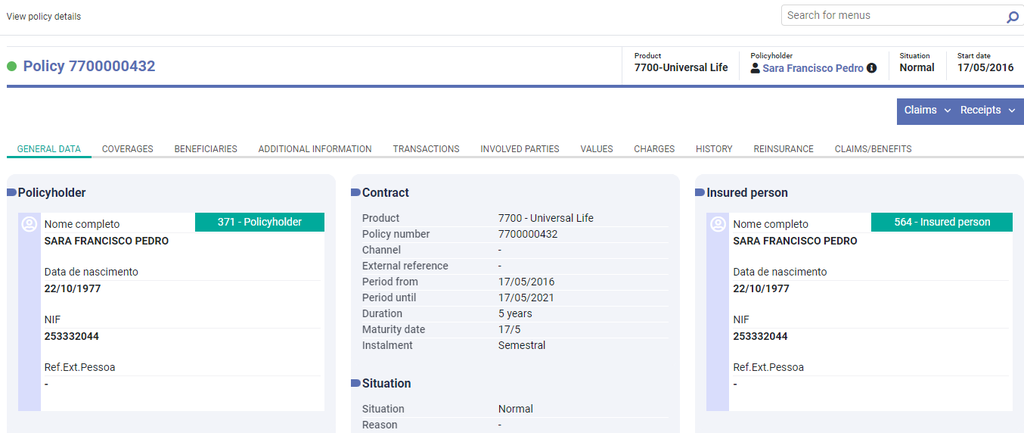

**Solution**

[figure not shown]

**Configuration required:** Yes

*CODE-161689 | Cleva Life v7 | 7.11 | FDT | All markets*